# Spline based survival model in stan

Produce a posterior for the survival curve:

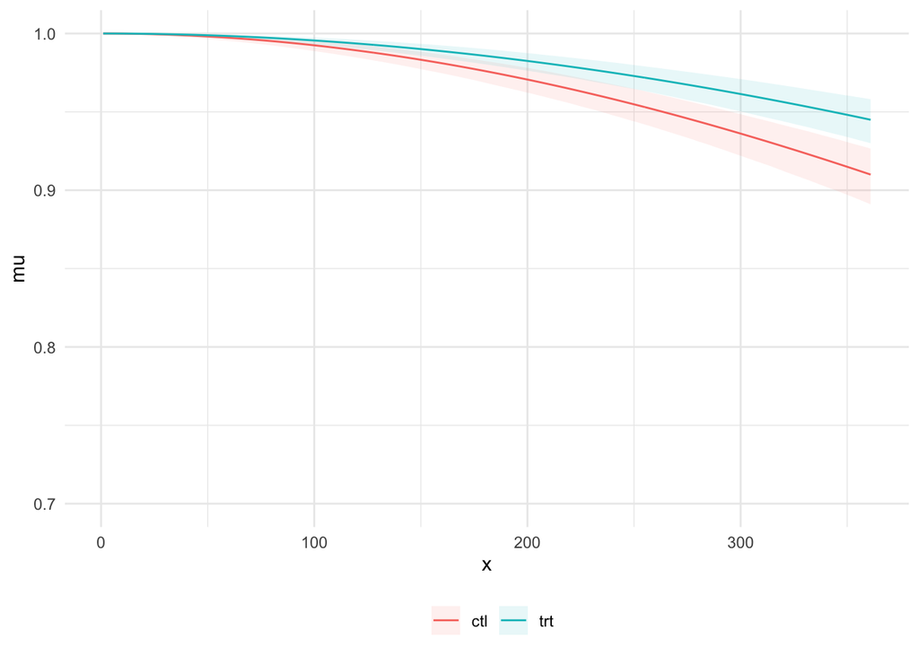

```r
d_post <- data.table(m1$draws(variables = c("surv0", "surv1"), format = "matrix"))
d_post <- melt(d_post, measure.vars = names(d_post))
d_post[variable %like% "surv0", trt := 0]
d_post[variable %like% "surv1", trt := 1]
d_fig <- copy(d_post)

d_fig[, x := gsub(".*\\[", "", variable)]
d_fig[, x := gsub("\\]", "", x)]
d_fig[, x := as.numeric(x)]

d_fig <- d_fig[
  , .(mu = mean(value),
      q_025 = quantile(value, prob = 0.025),
      q_975 = quantile(value, prob = 0.975)), keyby = .(trt, x)]
d_fig[, trt := factor(trt, levels = 0:1, labels = c("ctl", "trt"))]

ggplot(d_fig, aes(x = x, y = mu, group = trt, col = trt)) +
  geom_ribbon(aes(ymin = q_025, ymax = q_975, fill = trt), alpha = 0.1, col = NA) +
  geom_line() +
  scale_y_continuous(limits = c(0.7, 1), breaks = seq(0.7, 1, by = 0.1)) +
  scale_color_discrete("") +
  scale_fill_discrete("") +
  theme_minimal() +
  theme(
    legend.position = "bottom"
  )
```

Posterior on the median survival time, the time at which 50% of the cohort has experienced the occurrence of the event, e.g. a medical attendance for RSV ARI.

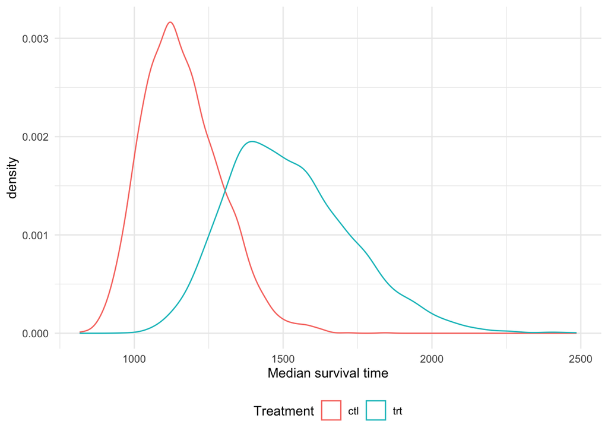

```r
d_post <- data.table(m1$draws(variables = c("scale0", "scale1"), format = "matrix"))

d_fig <- melt(d_post, measure.vars = names(d_post), variable.name = "trt")

d_fig[, trt := factor(trt, levels = c("scale0", "scale1"), labels = c("ctl", "trt"))]

ggplot(d_fig, aes(x = value, group = trt, col = trt)) +
  geom_density() +
  scale_x_continuous("Median survival time") +
  scale_color_discrete("Treatment") +
  theme_minimal() +
  theme(
    legend.position = "bottom"
  )
```

Estimate the posterior for restricted mean survival time (by treatment group) by integrating under the survival curve function for each draw from the posterior.

The RMST can be interpreted as the average survival time (i.e. time without the event, here being occurrence of RSV) during a defined time period ranging from time 0 to a specific follow-up time point.

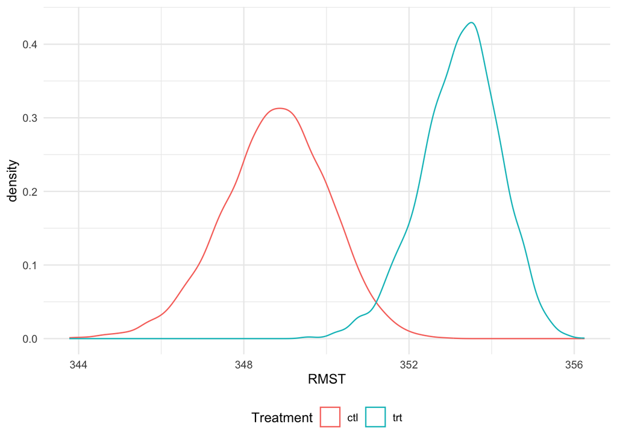

```r
# Define the function to integrate
integrand_1 <- function(
    x, mu, shape) {

  a = exp(mu)
  S = 1 / (1 + (x/a)^shape)
  S

}


d_post <- data.table(m1$draws(variables = c("gamma", "shape"), format = "matrix"))
names(d_post) <- c(paste0("gamma", 1:2), "shape")
i <- 1
m_rmst <- matrix(NA, ncol = 2, nrow = nrow(d_post))
for(i in 1:nrow(d_post)){
  m_rmst[i, 1] <- integrate(
    integrand_1, lower = 0, upper = 360,
    mu = d_post$gamma1[i],
    shape = d_post$shape[i])$value
  m_rmst[i, 2] <- integrate(
    integrand_1, lower = 0, upper = 360,
    mu = d_post$gamma1[i] + d_post$gamma2[i],
    shape = d_post$shape[i])$value
}



d_rmst <- data.table(m_rmst)
names(d_rmst) <- paste0(0:1)

rmst_diff <- d_rmst$`1` -  d_rmst$`0`


d_fig <- melt(d_rmst, measure.vars = names(d_rmst), variable.name = "trt")

d_fig[, trt := factor(trt, levels = 0:1, labels = c("ctl", "trt"))]

ggplot(d_fig, aes(x = value, group = trt, col = trt)) +
  geom_density() +
  scale_x_continuous("RMST") +
  scale_color_discrete("Treatment") +
  theme_minimal() +
  theme(
    legend.position = "bottom"
  )
```

```r
names(d_rmst) <- paste0("rmst", 0:1)
d_rmst[, diff := rmst1 - rmst0]
```

From here, we could evaluate differences in the RMST between groups considering what level of improvement in the mean survival to 360 days would be warranted to decide on adopting the treatment over the control.

Note that I have assumed a log-logistic parametric assumption here, primarily because I wanted something similar to a log-normal but more tractable. Other distributional assumptions might be more suitable. For example, if the data have a peaked hazard followed by a decline, then standard log-logistic or generalized log-logistic may work well. However, if the hazard function is more complex (e.g. bathtub shape, non-monotonic tail behavior etc), the Generalized F or Burr distributions might be better. Weibull or gamma models are simpler if only a monotonically increasing or decreasing hazard is required. All of these are reasonably straight forward to code up.

## References

1. Sun J. Statistical analysis of interval censored failure time data. Springer; 2006.

2. Christensen R. Bayesian ideas and data analysis. CRC Press; 2011.

3. Collett D. Modelling survival data in medical research. CRC Press; 2015.

4. Cleves M. Introduction to survival analysis using stata. Stata Press; 2010.